# Business Statistics Assessment IB94X0 2020-2021 #1

2092410

```r
# import useful packages
library(tidyverse)
library(emmeans)
library(gridExtra)
options(width=100)
```

Rename this file and the folder it is in with your student number (e.g., “1912345.Rmd”)

Submit this file and the knitted html as a zip file (e.g., 1912345.zip) *by right clicking on the folder to zip it*. That is, the zip file 1912345.zip should contain the folder 1912345 with *only* the files 1912345.Rmd and 1912345.html

# Question 1 Section 1

Figure 1 is the histogram of sales differences of stores in percentage. From period 1 to period 2, the sales difference of stores in trial increases 1.42% 95% CI[0.85% 1.98%]. The sales difference of stores not in trial only increases 0.1% 95% CI[-0.45% 0.65%]. Then, the new layout increases 1.31% 95% CI[0.53%, 2.1%] of sales difference of stores. This improvement is significant, $t(538) = 3.27$, $p = 0.0011$.

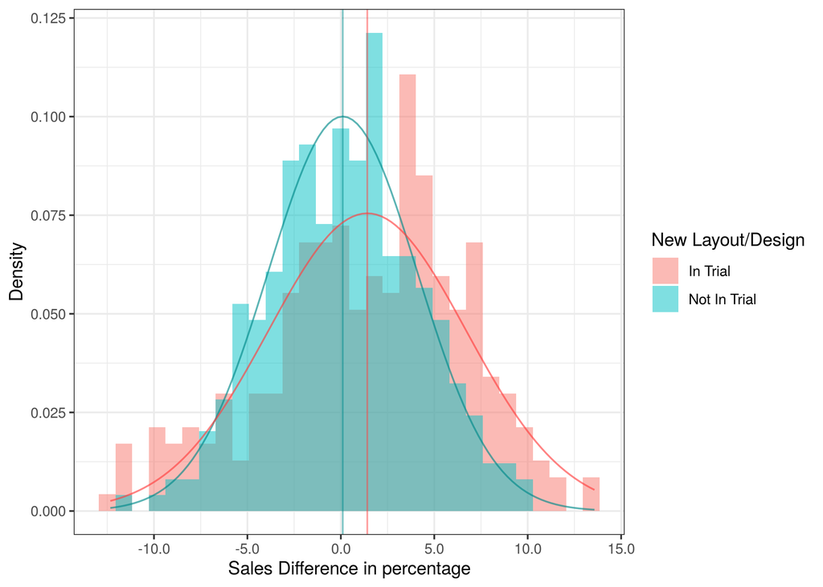

Figure 1. A histogram of the sales difference of stores. New design stores and ordinary stores are specified by different colours.

I prefer using **percentage data** while practicing *ANOVA* to examine the effect of the new layout. Since some of stores generally have much higher sales than the others, only examining the sales difference is insufficient. For example, the store, whose Outlet_ID is *“EhJV”*, has a fewer sales improvement ($577221.4$ GBP) in GBP than the store *“JI92”* ($684439.4$ GBP). Nonetheless, the original sales of the store *“EhJV”* ($6821444$ GBP) is much lower than that of the store *“JI92”* ($15629310$ GBP). Actually, this store is better as it has a higher increasing rate, $8.46%$. Therefore, I prefer percentage measure while performing ANOVA.

On the other hand, since each row of sales_1 and sales_2 are the multiple measurements from the same outlet, *repeated measure ANOVA* is performed to correctly control the link between sales_1 and sales2. In this case, sales differences are not needed, so I simply use the GBP data here.

# Question 2 Section 1

Figure 2 presents the sales difference in percentage by different outlet types. There is a strong interaction between intrial and outlettype, $F(2, 534) = 57.08$. That means a different effect in different outlet types does exist. For **community_convenience** outlets, stores in trial get 3.49% 95% CI[2.56% 4.43%] of sales improvement more than stores without any change, $t(534) = 7.33$, $p < 0.0001$. For **superstores**, stores in trial gets 3.48% 95% CI[2% 4.96%] of sales improvement more than stores not in trial, $t(534) = 4.625$, $p < 0.0001$. However, the pattern of **city_centre_convenience** outlets is different. The percentage of sales difference of stores in trial is 4.39% 95% CI[-5.61% -3.18%] **lower** than that of stores not in trial, $t(534) = -7.11$, $p < 0.0001$. Therefore, the effect of the new store design is negative to **city_centre_convenience** outlets.

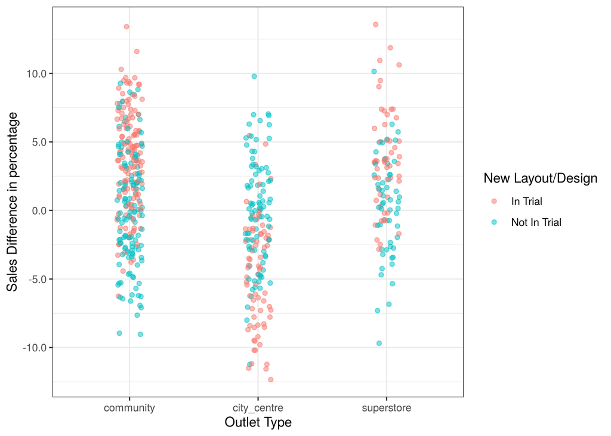

Figure 2. A scatter plot of the sales difference in percentage by different types of outlets. New design stores and ordinary stores are specified by different colours.

Figure 3 shows the relationship between sales difference in percentage and staff turnover rate. It seems that the correlation between these two variables is **not significant** as those two lines vary without any pattern. Actually, **staff_turnover** is not a significant predictor of sales difference in the model, $F(1, 537) = 0.1289$, $p = 0.7197$.

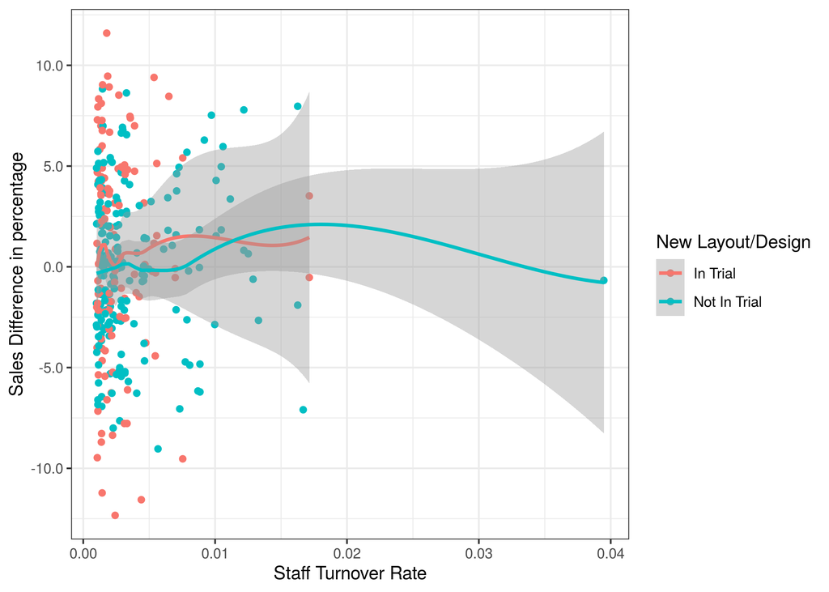

Figure 3. A scatter plot of sales difference by staff turnover rate. New design stores and ordinary stores are specified by different colours.

# Question 1 Section 2

Import and prepare the data

```r
# Read the data
sales = read_csv("sales_data.csv")
view(sales)
# Check the structure of the data
str(sales)
```

```
## tibble [540 × 6] (S3: spec_tbl_df/tbl_df/tbl/data.frame)
##  $ Outlet_ID     : chr [1:540] "7cbc" "rd0E" "fVhX" "HvIp" ...
##  $ outlettype    : chr [1:540] "community_convenience" "community_convenience" "community_convenience" "community_convenience" ...
##  $ sales_1       : num [1:540] 6484255 7096007 7823001 10865259 10825611 ...
##  $ sales_2       : num [1:540] 6439510 7345762 7832002 10630492 10611860 ...
##  $ intrial       : logi [1:540] TRUE TRUE TRUE FALSE FALSE TRUE ...
##  $ staff_turnover: num [1:540] 0.00111 0 0.00468 0 0.00206 ...
##  - attr(*, "spec")=
##   .. cols(
##   ..   Outlet_ID = col_character(),
##   ..   outlettype = col_character(),
##   ..   sales_1 = col_double(),
##   ..   sales_2 = col_double(),
##   ..   intrial = col_logical(),
##   ..   staff_turnover = col_double()
##   .. )
```

```r
# Check the levels of the variable "outlettype"
unique(sales$outlettype)
```

```
## [1] "community_convenience"   "city_centre_convenience" "superstore"
```

```r
# Create a data frame "sales.short" with correct data structures
sales.short = sales %>%
  mutate(outlettype = factor(outlettype, levels = c("community_convenience", "city_centre_convenience", "superstore")),
         sales_change_GBP = sales_2 - sales_1,
         sales_change_percentage = ((sales_2 - sales_1) / sales_1) * 100,
         intrial = factor(intrial, levels = c(TRUE, FALSE), labels = c("In Trial", "Not In Trial")))
view(sales.short)

# Create a data frame "sales.summary" to store the statistical data
sales.summary = sales.short %>%
  group_by(intrial) %>%
  summarise(n = n(),
            mean.GBP = mean(sales_change_GBP),
            mean.percentage = mean(sales_change_percentage),
            standard.deviation.GBP = sd(sales_change_GBP),
            standard.deviation.percentage = sd(sales_change_percentage))
view(sales.summary)
```

## Plot

### Exploring GBP measure

Plot a scatter plot for sales difference of stores in GBP by new layout in trial or not. It looks like there is a difference between new design stores and ordinary stores

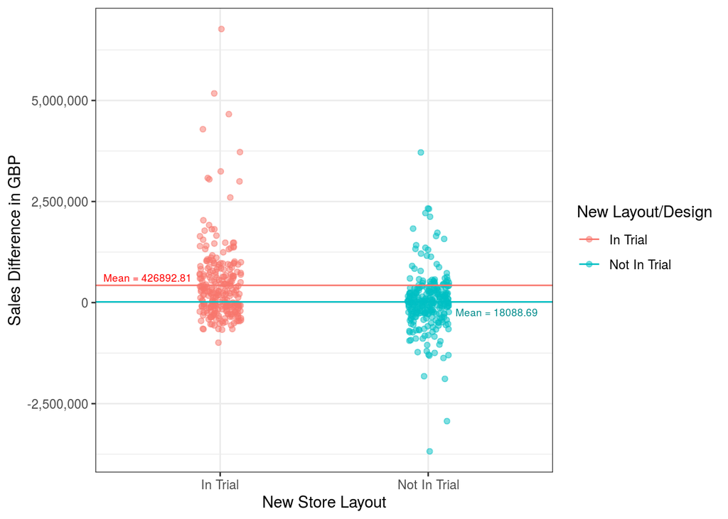

```r
ggplot(data = sales.short, aes(x = intrial, y = sales_change_GBP, col = intrial)) +
  geom_jitter(width = 0.1, alpha = 0.5) +
  geom_hline(data = sales.summary,
             mapping = aes(yintercept = mean.GBP, col = intrial)) +
  labs(x = "New Store Layout", y = "Sales Difference in GBP", col = "New Layout/Design") +
  theme_bw() +
  annotate(
    "text",
    x = 0.65, y = 3,
    label = paste0("Mean = ", round(sales.summary$mean.GBP[1], 2)),
    vjust = -2.8, size = 2.5, color = "red"
  ) +
  annotate(
    "text",
    x = 2.33, y = 3,
    label = paste0("Mean = ", round(sales.summary$mean.GBP[2], 2)),
    vjust = 1.8, size = 2.5, color = "cyan4"
  ) +
  scale_y_continuous(labels = scales::comma)
```

Plot a histogram for sales difference in GBP by intrial. It seems that there are higher sales for stores in trial.

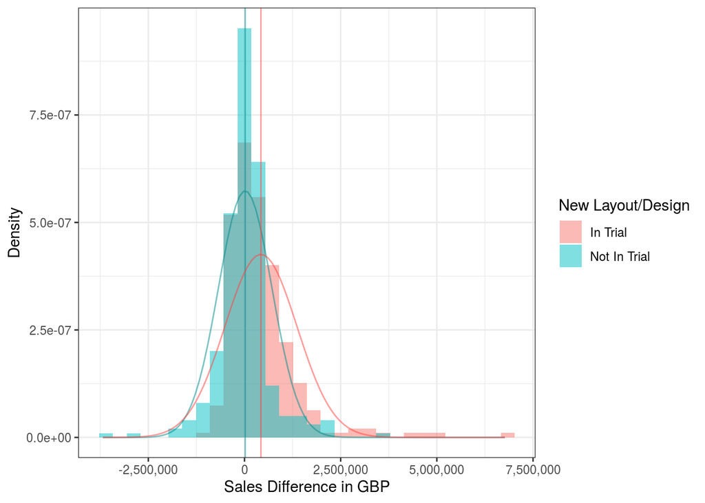

```r
ggplot(data = sales.short, aes(x = sales_change_GBP, fill = intrial)) +
  geom_histogram(aes(y = ..density..), alpha = 0.5, position = "identity") +
  theme_bw() +
  stat_function(fun=function(x) {dnorm(x,
                                       mean=sales.summary$mean.GBP[2],
                                       sd=sales.summary$standard.deviation.GBP[2])},
                col="cyan4", alpha = 0.3) +
  geom_vline(xintercept = sales.summary$mean.GBP[2], col="cyan4", alpha = 0.5) +
  stat_function(fun=function(x) {dnorm(x,
                                       mean=sales.summary$mean.GBP[1],
                                       sd=sales.summary$standard.deviation.GBP[1])},
                col="brown1", alpha = 0.3) +
  geom_vline(xintercept = sales.summary$mean.GBP[1], col="brown1", alpha = 0.5) +
  labs(x = "Sales Difference in GBP", y = "Density", fill = "New Layout/Design") +
  scale_x_continuous(labels = scales::comma)
```

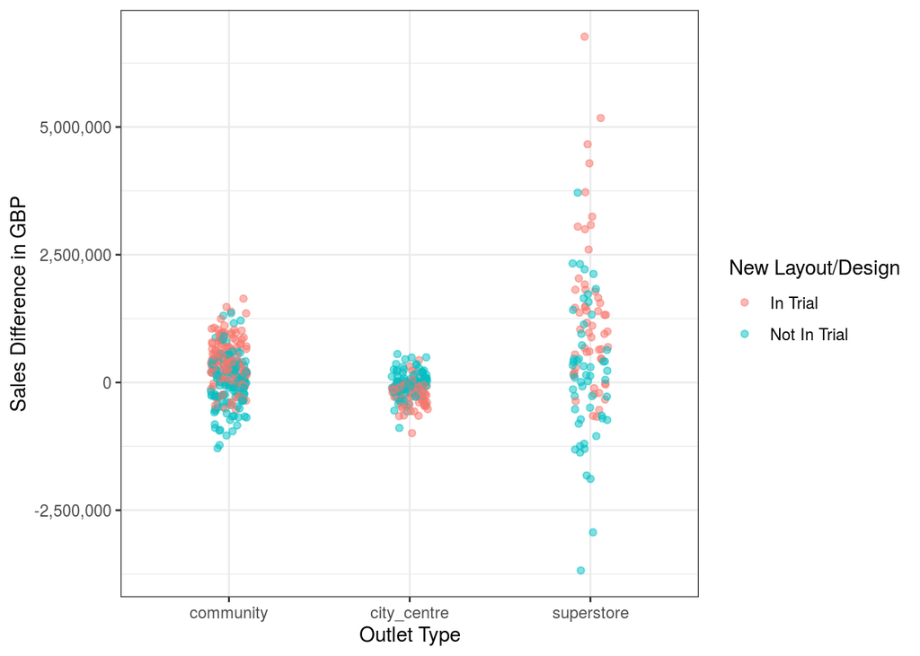

```r
ggplot(data = sales.short, aes(x = outlettype, y = sales_change_GBP, col = intrial)) +
  geom_jitter(width = 0.1, alpha = 0.5) +
  theme_bw() +
  labs(x = "Outlet Type",
       y = "Sales Difference in GBP",
       col = "New Layout/Design") +
  scale_y_continuous(labels = scales::comma) +
  scale_x_discrete(labels = c("community_convenience" = "community",
                              "city_centre_convenience" = "city_centre"))
```

Plot a scatter plot to check the relationship between sales difference and staff turnover rate. It seems that the correlation between these two variables is not significant

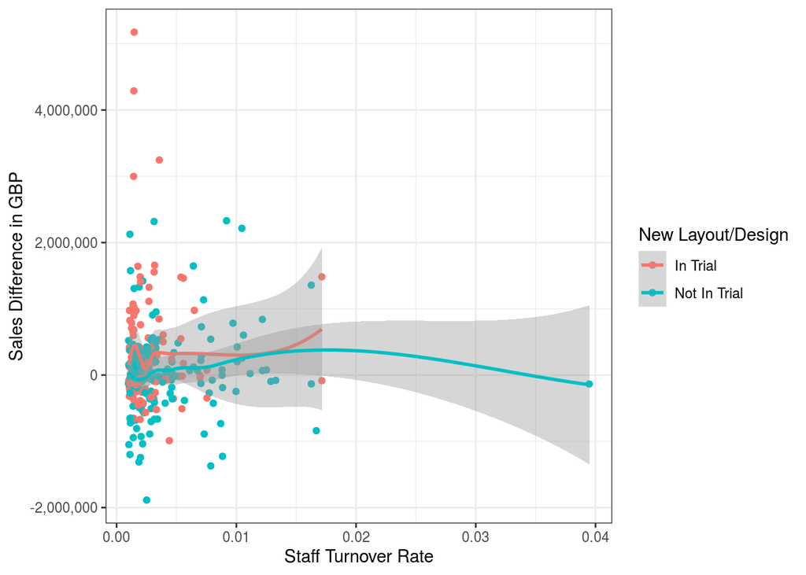

```r
ggplot(data = sales.short %>% filter(staff_turnover != 0),
       aes(x = staff_turnover, y = sales_change_GBP, col = intrial)) +
  geom_point() +
  theme_bw() +
  geom_smooth() +
  labs(x="Staff Turnover Rate", y="Sales Difference in GBP", col = "New Layout/Design") +
  scale_y_continuous(labels = scales::comma)
```

### Exploring percentage measure

Plot a scatter plot for percentage of sales difference of stores by new layout in trial or not. It looks like the average of sales difference of stores in trial is slightly higher than that of stores not in trial

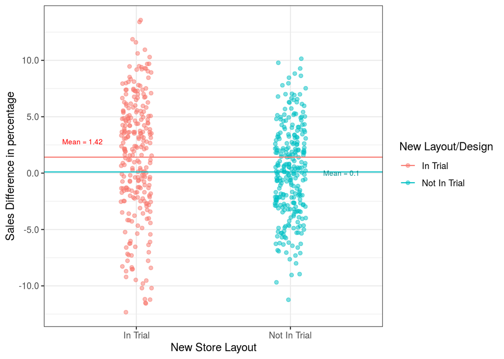

```r
ggplot(data = sales.short, aes(x = intrial, y = sales_change_percentage, col = intrial)) +
  geom_jitter(width = 0.1, alpha = 0.5) +
  geom_hline(data = sales.summary,
             mapping = aes(yintercept = mean.percentage, col = intrial)) +
  labs(x = "New Store Layout", y = "Sales Difference in percentage", col = "New Layout/Design") +
  theme_bw() +
  annotate(
    "text",
    x = 0.65, y = 3,
    label = paste0("Mean = ", round(sales.summary$mean.percentage[1], 2)),
    vjust = 1, size = 2.5, color = "red"
  ) +
  annotate(
    "text",
    x = 2.33, y = 3,
    label = paste0("Mean = ", round(sales.summary$mean.percentage[2], 2)),
    vjust = 7, size = 2.5, color = "cyan4"
  ) +
  scale_y_continuous(labels = scales::comma)
```

Plot a histogram for sales difference in percentage by intrial. It seems that there are higher sales for stores in trial.

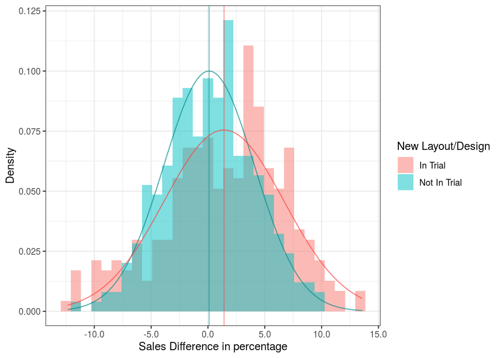

```r
( sales.difference.in.percentage.histogram = ggplot(data = sales.short,
                                                  aes(x = sales_change_percentage, fill = intrial)) +
  geom_histogram(aes(y = ..density..), alpha = 0.5, position = "identity") +
  # geom_histogram(alpha = 0.5, position = "identity") +
  theme_bw() +
  stat_function(fun=function(x) {dnorm(x,
                                       mean=sales.summary$mean.percentage[2],
                                       sd=sales.summary$standard.deviation.percentage[2])},
                col="cyan4", alpha = 0.4) +
  geom_vline(xintercept = sales.summary$mean.percentage[2], col="cyan4", alpha = 0.5) +
  stat_function(fun=function(x) {dnorm(x,
                                       mean=sales.summary$mean.percentage[1],
                                       sd=sales.summary$standard.deviation.percentage[1])},
                col="brown1", alpha = 0.4) +
  geom_vline(xintercept = sales.summary$mean.percentage[1], col="brown1", alpha = 0.5) +
  labs(x = "Sales Difference in percentage", y = "Density", fill = "New Layout/Design") +
  scale_x_continuous(labels = scales::comma) )
```

Save the plot

```r
ggsave(sales.difference.in.percentage.histogram, file="sales.difference.in.percentage.histogram.png")
```

Plot a scatter plot for the sales difference in percentage by different outlet types. It looks like new layout and design would lead to higher sales for community_convenience stores and superstores. However, new store layout statistically produce a negative effect to the sales for city_centre_convenience stores.

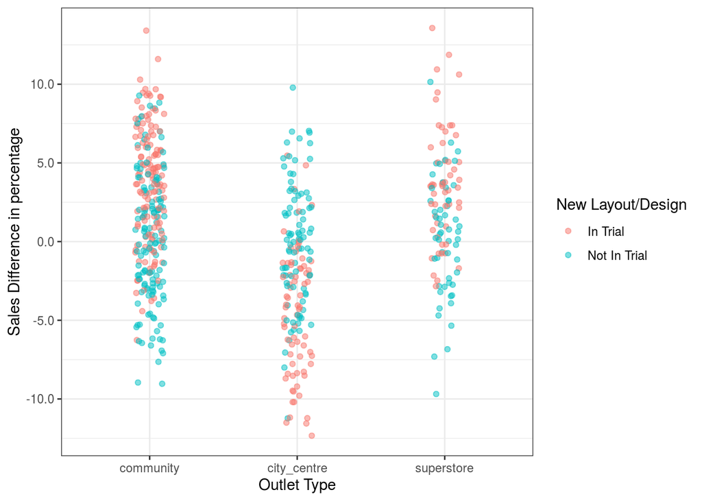

```r
( sales.difference.by.outlettype.and.intrial = ggplot(data = sales.short,
                                                      aes(x = outlettype,
                                                          y = sales_change_percentage,
                                                          col = intrial)) +
  geom_jitter(width = 0.1, alpha = 0.5) +
  theme_bw() +
  labs(x = "Outlet Type",
       y = "Sales Difference in percentage",
       col = "New Layout/Design") +
  scale_y_continuous(labels = scales::comma) +
  scale_x_discrete(labels = c("community_convenience" = "community",
                              "city_centre_convenience" = "city_centre")) )
```

Save the plot

```r
ggsave(sales.difference.by.outlettype.and.intrial, file="sales.difference.by.outlettype.and.intrial.png")
```

Plot a scatter plot to check the relationship between sales difference in percentage and staff turnover rate. It seems that the correlation between these two variables is not significant as those two lines vary without any pattern

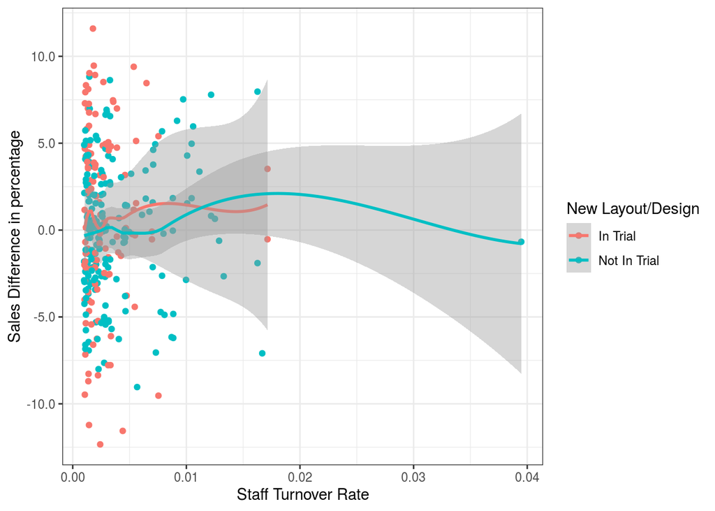

```r
( sales.difference.by.staffturnover.and.intrial = ggplot(data = sales.short %>%
                                                         filter(staff_turnover != 0),
       aes(x = staff_turnover, y = sales_change_percentage, col = intrial)) +
  geom_point() +
  theme_bw() +
  geom_smooth() +
  labs(x="Staff Turnover Rate", y="Sales Difference in percentage", col = "New Layout/Design") +
  scale_y_continuous(labels = scales::comma) )
```

Save the plot

```r
ggsave(sales.difference.by.staffturnover.and.intrial, file="sales.difference.by.staffturnover.and.intrial.png")
```

## Exploring the effect of new layout/design

### Model1: Using GBP data

```r
# Build a linear model of sales_change_GBP by intrial
m.GBP.sales.intrial = lm(sales_change_GBP~intrial, data = sales.short)
# Use anova to check the significance of predictor "intrial"
anova(m.GBP.sales.intrial)
```

```
## Analysis of Variance Table
##
## Response: sales_change_GBP
##            Df     Sum Sq    Mean Sq F value  Pr(>F)
## intrial     1 2.2546e+13 2.2546e+13  33.354 1.3e-08 ***
## Residuals 538 3.6367e+14 6.7597e+11
## ---
## Signif. codes:  0 '***' 0.001 '**' 0.01 '*' 0.05 '.' 0.1 ' ' 1
```

```r
# Check the outcome of the model "m.GBP.sales.intrial"
summary(m.GBP.sales.intrial)
```

```
##
## Call:
## lm(formula = sales_change_GBP ~ intrial, data = sales.short)
##
## Residuals:
##      Min       1Q   Median       3Q      Max
## -3697663  -466616   -59568   268684  6341014
##
## Coefficients:
##                     Estimate Std. Error t value Pr(>|t|)
## (Intercept)           426893      50697   8.420 3.42e-16 ***
## intrialNot In Trial  -408804      70785  -5.775 1.30e-08 ***
## ---
## Signif. codes:  0 '***' 0.001 '**' 0.01 '*' 0.05 '.' 0.1 ' ' 1
##
## Residual standard error: 822200 on 538 degrees of freedom
## Multiple R-squared:  0.05838,    Adjusted R-squared:  0.05663
## F-statistic: 33.35 on 1 and 538 DF,  p-value: 1.3e-08
```

The new store layout/design **significantly** changes average sales in GBP, $t(538) = -5.775$, $p < 0.0001$

```r
# Check the individual means and confidence intervals for each category
( GBP.sales.intrial.emm = emmeans(m.GBP.sales.intrial, ~intrial) )
```

```
##  intrial      emmean    SE  df lower.CL upper.CL
##  In Trial     426893 50697 538   327304   526482
##  Not In Trial  18089 49400 538   -78951   115128
##
## Confidence level used: 0.95
```

contrast

```r
# Set up the contrast tibble
Trial.notTrial.GBP.contrast = tibble(Trial.minus.notTrial = c(1, -1))

# Hypothesis Testing
( contrast(GBP.sales.intrial.emm, Trial.notTrial.GBP.contrast) )
```

```
##  contrast             estimate    SE  df t.ratio p.value
##  Trial.minus.notTrial   408804 70785 538 5.775   <.0001
```

```r
# Estimation
( GBP.sales.intrial.confint = confint(contrast(GBP.sales.intrial.emm, Trial.notTrial.GBP.contrast)) )
```

```
##  contrast             estimate    SE  df lower.CL upper.CL
##  Trial.minus.notTrial   408804 70785 538   269755   547853
##
## Confidence level used: 0.95
```

The sale increase of stores in trial is 408804 GBP 95% CI[269755, 547853] higher than that of stores not in trial, $t(538) = 5.78$, $p < 0.0001$.

Presentation

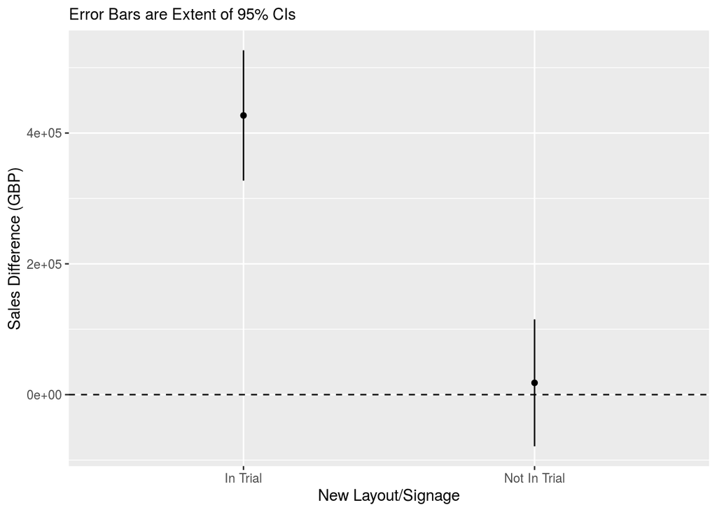

```r
ggplot(summary(GBP.sales.intrial.emm),
       aes(x = intrial, y = emmean, ymax = upper.CL, ymin = lower.CL)) +
  geom_point() +
  geom_linerange() +
  labs(x = "New Layout/Signage", y = "Sales Difference (GBP)", subtitle="Error Bars are Extent of 95% CIs") +
  geom_hline(yintercept = 0, linetype = "dashed")
```

The figure shows the sales difference in GBP from each type of stores. Sales difference of stores in trial is higher than sales difference of stores not in trial.

### Model2: Using Percentage data

```r
# Build a linear model of sales_change_percentage by intrial
m.per.sales.intrial = lm(sales_change_percentage~intrial, data = sales.short)
# Use anova to check the significance of predictor "intrial"
anova(m.per.sales.intrial)
```

```
## Analysis of Variance Table
##
## Response: sales_change_percentage
##            Df  Sum Sq Mean Sq F value   Pr(>F)
## intrial     1   232.8 232.819  10.696 0.001143 **
## Residuals 538 11710.9  21.768
## ---
## Signif. codes:  0 '***' 0.001 '**' 0.01 '*' 0.05 '.' 0.1 ' ' 1
```

```r
# Check the outcome of the model "m.per.sales.intrial"
summary(m.per.sales.intrial)
```

```
##
## Call:
## lm(formula = sales_change_percentage ~ intrial, data = sales.short)
##
## Residuals:
##      Min       1Q   Median       3Q      Max
## -13.7504  -2.9760   0.2808   3.2649  12.1563
##
## Coefficients:
##                     Estimate Std. Error t value Pr(>|t|)
## (Intercept)           1.4156     0.2877    4.92 1.15e-06 ***
## intrialNot In Trial  -1.3137     0.4017   -3.27  0.00114 **
## ---
## Signif. codes:  0 '***' 0.001 '**' 0.01 '*' 0.05 '.' 0.1 ' ' 1
##
## Residual standard error: 4.666 on 538 degrees of freedom
## Multiple R-squared:  0.01949,    Adjusted R-squared:  0.01767
## F-statistic:  10.7 on 1 and 538 DF,  p-value: 0.001143
```

The new store layout/design significantly changes average sales in percentage, $t(538) = -3.27$, $p = 0.001$

```r
# Check the individual means and confidence intervals for each category
( per.sales.intrial.emm = emmeans(m.per.sales.intrial, ~intrial) )
```

```
##  intrial      emmean    SE  df lower.CL upper.CL
##  In Trial      1.416 0.288 538    0.850    1.981
##  Not In Trial  0.102 0.280 538   -0.449    0.653
##
## Confidence level used: 0.95
```

contrast

```r
# Set up the contrast tibble
Trial.notTrial.per.contrast = tibble(Trial.minus.notTrial = c(1, -1))

# Hypothesis Testing
( contrast(per.sales.intrial.emm, Trial.notTrial.per.contrast) )
```

```
##  contrast             estimate    SE  df t.ratio p.value
##  Trial.minus.notTrial     1.31 0.402 538 3.270   0.0011
```

```r
# Estimation
( confint(contrast(per.sales.intrial.emm, Trial.notTrial.per.contrast)) )
```

```
##  contrast             estimate    SE  df lower.CL upper.CL
##  Trial.minus.notTrial     1.31 0.402 538    0.525      2.1
##
## Confidence level used: 0.95
```

The percentage of sale increase of stores in trial is 1.31% 95% CI[0.53%, 2.1%] higher than the percentage of sale increase of stores not in trial, $t(538) = 3.27$, $p = 0.0011$.

Presentation

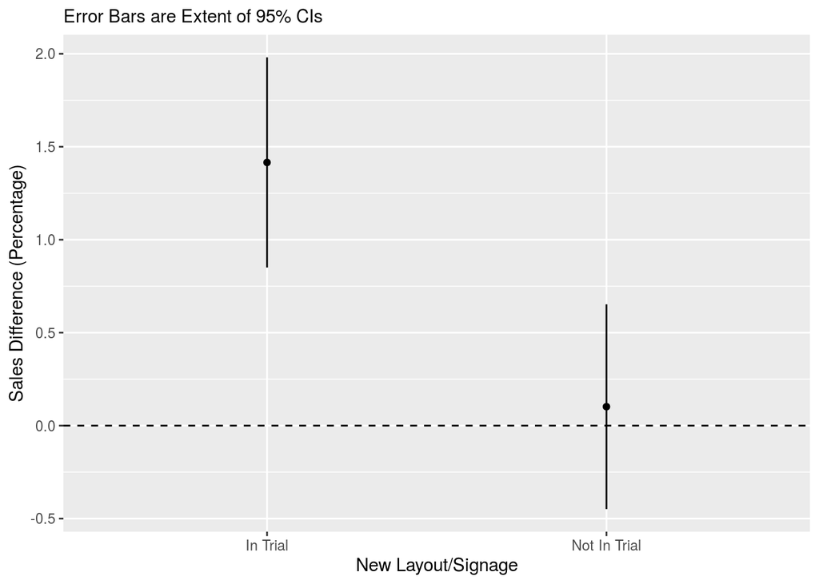

```r
ggplot(summary(per.sales.intrial.emm),
       aes(x = intrial, y = emmean, ymax = upper.CL, ymin = lower.CL)) +
  geom_point() +
  geom_linerange() +
  labs(x = "New Layout/Signage", y = "Sales Difference (Percentage)", subtitle="Error Bars are Extent of 95% CIs") +
  geom_hline(yintercept = 0, linetype = "dashed")
```

The figure shows the sales difference in percentage from each type of stores. Sales difference of stores in trial is higher than sales difference of stores not in trial.

## Controlling the link between sales_1 and sales_2

```r
# Create a longer dataset to gather the variable "sales_1" and the variable "sales_2"
sales.long = pivot_longer(sales, c(sales_1, sales_2),
                          names_to = "Period",
                          values_to = "Sales",
                          names_transform = list(Period = factor,
                                                 Sales = as.numeric),
                          names_prefix = "sales_") %>%
  mutate(outlettype = factor(outlettype, levels = c("community_convenience", "city_centre_convenience", "superstore")),
         intrial = factor(intrial, levels = c(TRUE, FALSE), labels = c("In Trial", "Not In Trial")))
view(sales.long)
```

### Model3: Repeated Measure ANOVA

```r
contrasts(sales.long$Period) = contr.sum
# Repeated Measure ANOVA
m.sales.period = aov(Sales~Period*intrial + Error(Outlet_ID/Period),
                             data = sales.long)
# Check the outcome of the model "m.sales.period"
summary(m.sales.period)
```

```
##
## Error: Outlet_ID
##            Df    Sum Sq   Mean Sq F value Pr(>F)
## intrial     1 1.557e+14 1.557e+14   0.525  0.469
## Residuals 538 1.594e+17 2.963e+14
##
## Error: Outlet_ID:Period
##                 Df    Sum Sq   Mean Sq F value   Pr(>F)
## Period           1 1.274e+13 1.274e+13   37.68 1.62e-09 ***
## Period:intrial   1 1.127e+13 1.127e+13   33.35 1.30e-08 ***
## Residuals      538 1.818e+14 3.380e+11
## ---
## Signif. codes:  0 '***' 0.001 '**' 0.01 '*' 0.05 '.' 0.1 ' ' 1
```

```r
# Check the individual means and confidence intervals for each category (Period + intrial)
( sales.period.emm = emmeans(m.sales.period, ~Period + intrial) )
```

```
## Note: re-fitting model with sum-to-zero contrasts
```

```
##  Period intrial        emmean     SE  df lower.CL upper.CL
##  1      In Trial     14419856 741311 539 12963645 15876067
##  2      In Trial     14846749 741311 539 13390538 16302960
##  1      Not In Trial 13864644 741289 539 12408475 15320812
##  2      Not In Trial 13882733 741289 539 12426564 15338901
##
## Warning: EMMs are biased unless design is perfectly balanced
## Confidence level used: 0.95
```

Contrast

```r
# Set up the contrast tibble
Period.contrast = tibble(Period2.minus.Period1 = c(-1, 1, 1, -1))
# Hypothesis Testing
( contrast(sales.period.emm, Period.contrast) )
```

```
##  contrast              estimate    SE  df t.ratio p.value
##  Period2.minus.Period1   408804 70785 538 5.775   <.0001
```

```r
# Estimation
( confint(contrast(sales.period.emm, Period.contrast)) )
```

```
##  contrast              estimate    SE  df lower.CL upper.CL
##  Period2.minus.Period1   408804 70785 538   269755   547853
##
## Confidence level used: 0.95
```

The sales difference for stores in trial is 408804 GBP 95% CI[269755, 547853] higher than the sale difference for stores not in trial, $t(538) = 5.775$, $p-value < 0.0001$.

# Question 2 Section 2

## The different effect in different outlet types

### Model4: Interaction between intrial and outlettype

```r
# Build a linear model for sales_change_percentage by intrial, outlettype and the interaction between intrial and outlettype
m.sales.intrial.outlettype = lm(sales_change_percentage~intrial*outlettype, data = sales.short)
# Implement ANOVA to check the significance of the interaction between intrial and outlettype in the model
anova(m.sales.intrial.outlettype)
```

```
## Analysis of Variance Table
##
## Response: sales_change_percentage
##                     Df Sum Sq Mean Sq F value    Pr(>F)
## intrial              1  232.8  232.82  15.188 0.0001097 ***
## outlettype           2 1775.4  887.72  57.912 < 2.2e-16 ***
## intrial:outlettype   2 1749.9  874.93  57.078 < 2.2e-16 ***
## Residuals          534 8185.6   15.33
## ---
## Signif. codes:  0 '***' 0.001 '**' 0.01 '*' 0.05 '.' 0.1 ' ' 1
```

### Interpret the different effect in different outlet types

```r
# Check the individual means and confidence intervals for each category (intrial + outlettype)
( sales.intrial.outlettype.emm = emmeans(m.sales.intrial.outlettype, ~intrial + outlettype) )
```

```
##  intrial      outlettype               emmean    SE  df lower.CL upper.CL
##  In Trial     community_convenience    3.6624 0.336 534    3.003    4.322
##  Not In Trial community_convenience    0.1710 0.338 534   -0.493    0.835
##  In Trial     city_centre_convenience -4.4865 0.458 534   -5.387   -3.586
##  Not In Trial city_centre_convenience -0.0925 0.415 534   -0.908    0.723
##  In Trial     superstore               3.7355 0.533 534    2.689    4.782
##  Not In Trial superstore               0.2508 0.533 534   -0.796    1.297
##
## Confidence level used: 0.95
```

contrast

```r
# Set up the contrast tibble
outlet_contrast = tibble(community_convenience = c(1, -1, 0, 0, 0, 0),
                         city_centre_convenience = c(0, 0, 1, -1, 0, 0),
                         superstore = c(0, 0, 0, 0, 1, -1))
# Hypothesis Testing
( contrast(sales.intrial.outlettype.emm, outlet_contrast) )
```

```
##  contrast                estimate    SE  df t.ratio p.value
##  community_convenience       3.49 0.477 534  7.326  <.0001
##  city_centre_convenience    -4.39 0.618 534 -7.107  <.0001
##  superstore                  3.48 0.753 534  4.625  <.0001
```

```r
# Estimation
( outlet_confint = confint(contrast(sales.intrial.outlettype.emm, outlet_contrast)) )
```

```
##  contrast                estimate    SE  df lower.CL upper.CL
##  community_convenience       3.49 0.477 534     2.56     4.43
##  city_centre_convenience    -4.39 0.618 534    -5.61    -3.18
##  superstore                  3.48 0.753 534     2.00     4.96
##
## Confidence level used: 0.95
```

### Presentation

[figure not shown]

```r
p2.1 = ggplot(summary(sales.intrial.outlettype.emm),
       aes(x = intrial, y = emmean, ymax = upper.CL, ymin = lower.CL, group = desc(outlettype))) +
  geom_point() +
  geom_linerange() +
  labs(x = "New Layout/Signage",
       y = "Sales Difference (GBP)",
       title = "Sales changed in GBP by intrial in different types of outlet") +
  facet_grid(.~outlettype) +
  geom_hline(yintercept = 0, col = "green")


outlet_confint = outlet_confint %>%
  mutate(contrast = factor(contrast, levels = c("community_convenience", "city_centre_convenience", "superstore")))
p2.2 = ggplot(outlet_confint,
       aes(x = contrast, y = estimate, ymax = upper.CL, ymin = lower.CL, group = contrast)) +
  geom_point() +
  geom_linerange() +
  labs(x = "Outlet types",
       y = "Difference sales improvement",
       title = "Difference sales improvement in different types of outlet") +
  geom_hline(yintercept = 0, col = "green")

grid.arrange(p2.1, p2.2, ncol = 1)
```

## Staff Turnover

### The improvement for adding staff turnover (without the interaction between intrial and outlettype)

```r
# Build a linear model for sales_change_percentage by intrial and staff_turnover
m.per.sales.intrial.staff_turnover = lm(sales_change_percentage~intrial+staff_turnover, data = sales.short)
# Use anova to check if the variable "staff_turnover" is a significant predictor
anova(m.per.sales.intrial, m.per.sales.intrial.staff_turnover)
```

```
## Analysis of Variance Table
##
## Model 1: sales_change_percentage ~ intrial
## Model 2: sales_change_percentage ~ intrial + staff_turnover
##   Res.Df   RSS Df Sum of Sq      F Pr(>F)
## 1    538 11711
## 2    537 11708  1    2.8104 0.1289 0.7197
```

*staff_turnover* is not a significant predictor of sales_change_percentage in the model, $F(1, 537) = 0.1289$, $p = 0.7197$

### The improvement for adding staff turnover (with the interaction between intrial and outlettype)

```r
# Build a linear model for sales_change_percentage by intrial, outlettype, the interaction between intrial and outlettype, and staff_turnover
m.sales.intrial.outlettype.staff_turnover = lm(sales_change_percentage~intrial*outlettype + staff_turnover,
                                               data = sales.short)
# Use anova to check if the variable "staff_turnover" is a significant predictor
anova(m.sales.intrial.outlettype, m.sales.intrial.outlettype.staff_turnover)
```

```
## Analysis of Variance Table
##
## Model 1: sales_change_percentage ~ intrial * outlettype
## Model 2: sales_change_percentage ~ intrial * outlettype + staff_turnover
##   Res.Df    RSS Df Sum of Sq      F Pr(>F)
## 1    534 8185.6
## 2    533 8180.4  1    5.2621 0.3429 0.5584
```

*staff_turnover* is not a significant predictor of sales_change_percentage in the model, $F(1, 533) = 0.3429$, $p = 0.5584$

*staff_turnover* in both models is not a significant predictor.